# RNA-Seq Analysis (ERP010786)

Anna Vines

22/12/2020

# Introduction

This analysis seeks to explore the differentially expressed genes found in listeria patients compared to healthy controls. The .rda data used in this analysis - ERP010786 - is publicly available and was taken from [Recount2](https://jhubiostatistics.shinyapps.io/recount/), where it had previously been prepared for downstream analysis. More information about ERP010786 can be found on its [NCBI SRA page](https://www.ncbi.nlm.nih.gov/Traces/study/?acc=ERP010786&o=acc_s%3Aa). In order to determine DEGs, as well as the top pathways as found through GSEA, R and various Bioconductor packages have been used including DESeq2 and MSigDB.

This report has been carried out as an RNA-Seq training project for Bishop Lab, UTSA and the Bioinformatics Research Network.

# Differential Expression Analysis

### Quality control checks

Prior to the performance of differential expression analysis, the data underwent a variance-stabilising transformation and then principal component analysis (PCA). The resulting plot shown below, coloured by condition of interest, shows large differences between biological groups and clustering within conditions. The heatmap showing sample-level distance also shows significant separation between conditions. Together, this signals that there are likely biological differences between conditions and the data appears to be high quality.

**The PCA plot of ERP010786:**

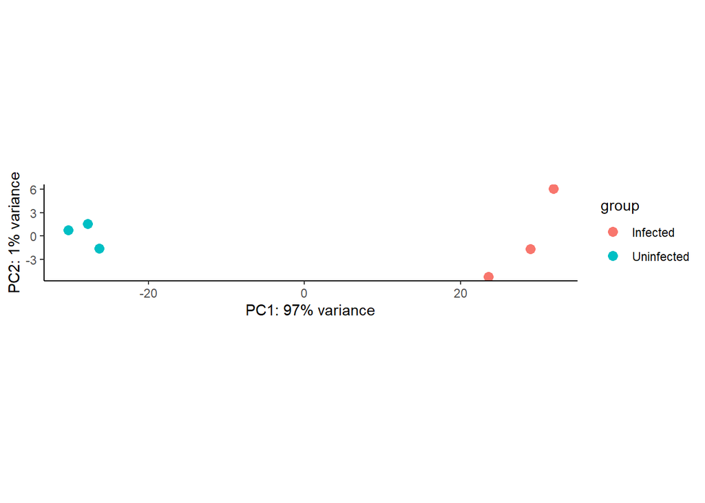

**The heatmap showing hierarchical clustering of ERP010786:**

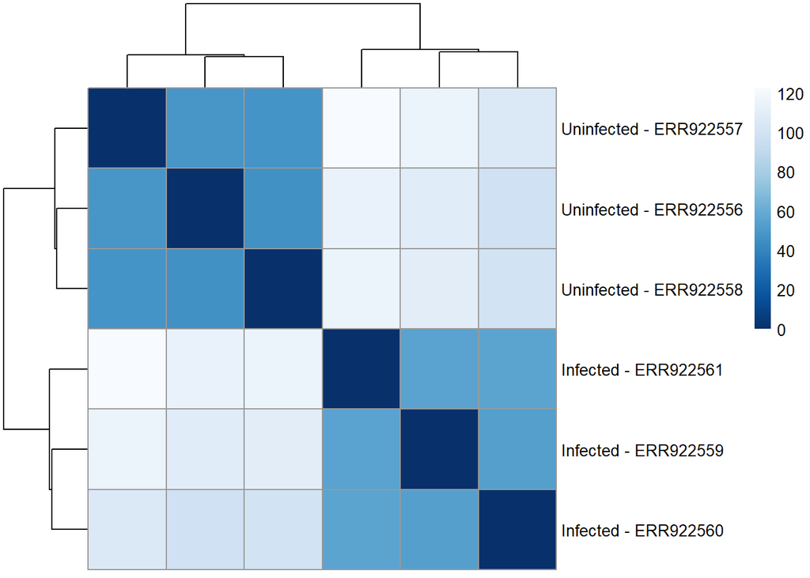

### Plots of differential expression

After checking the PCA plot above for clear clustering by condition, DE analysis was performed with DESeq2. The plot of dispersion estimates is encouraging, as it shows the data scattered around the curve but still following its shape, and dispersion decreases as mean expression levels increase. An MA plot was used to visualise gene expression changes between conditions. Both over and underexpressed genes were seen, with points correctly centred around the M=0 line.

**A dispersion plot of ERP010786:**

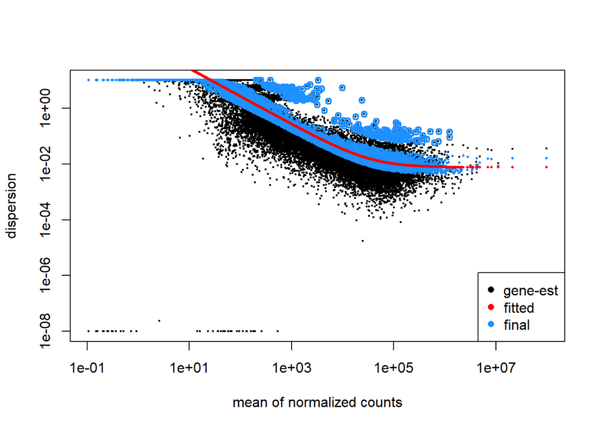

**An MA plot of DEGs from ERP010786:**

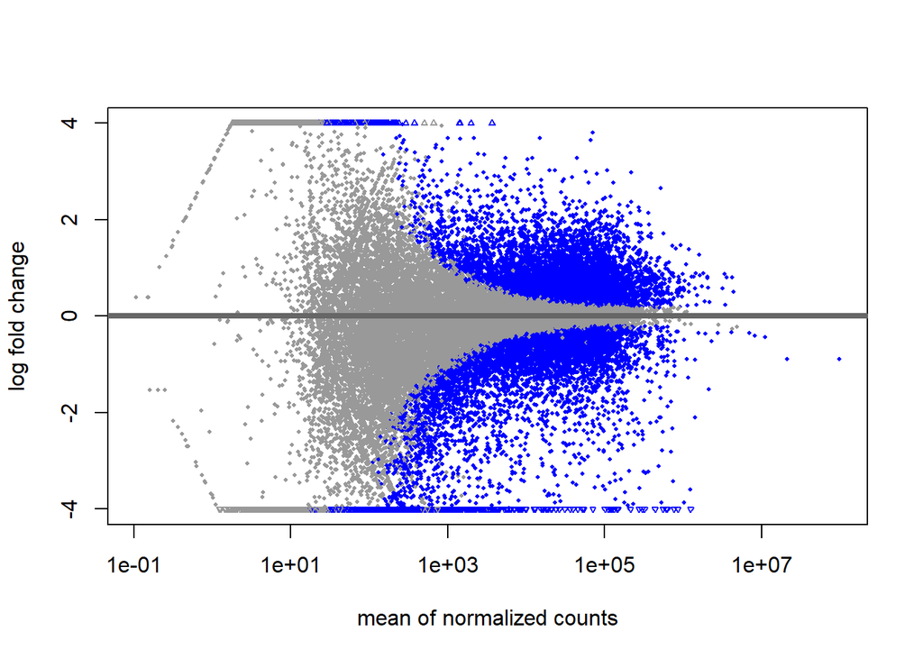

### Using a volcano plot to show statistical significance in differential expression

While the above plots give a sense of differential expression, they do not allow for an understanding of statistical significance. In order to do so, a volcano plot coloured by whether the p-adjusted value of a particular gene’s differential expression is less than or equal to 0.01 is produced. The volcano plot shows many statistically signficant differentially expressed genes.

**A volcano plot of the DEGs from ERP010786. Blue points are statistically significant:**

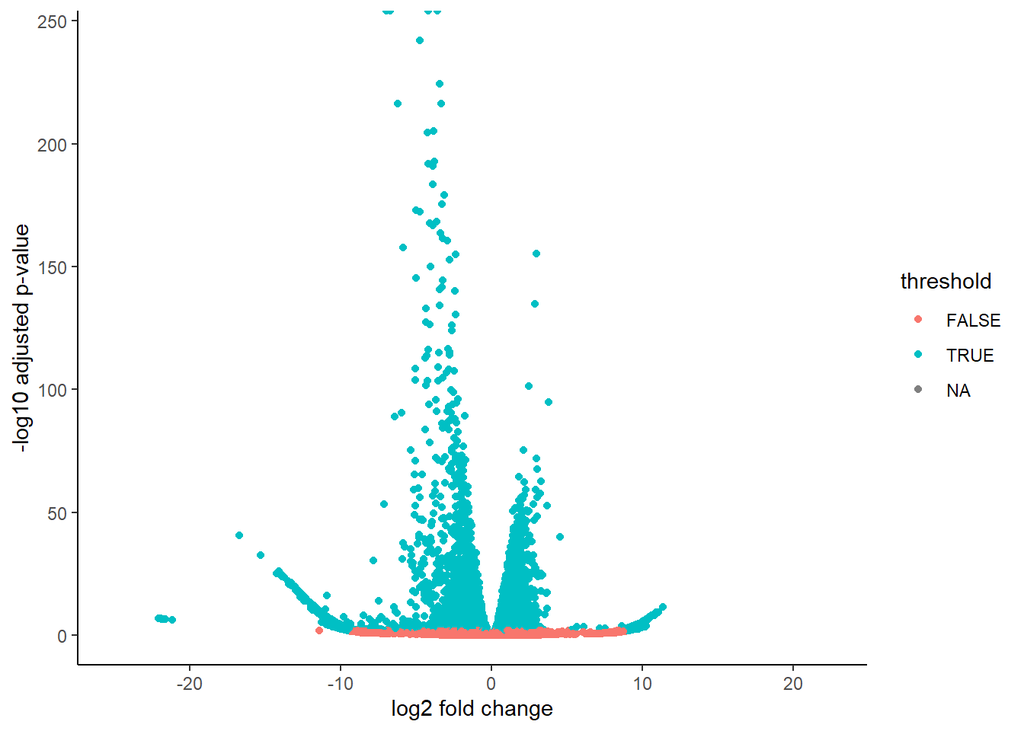

### Plotting the Top 20 Statistically Significant DE genes

Finally, a heatmap showing the top 20 statistically significant differentially expressed genes in infected patients compared to controls is created. This shows large differences between infected and uninfected samples. A searchable table of all statistically significant differentially expressed genes (ordered by p-adjusted value) can be found below the heatmap.

**A heatmap showing the top 20 DE genes:**

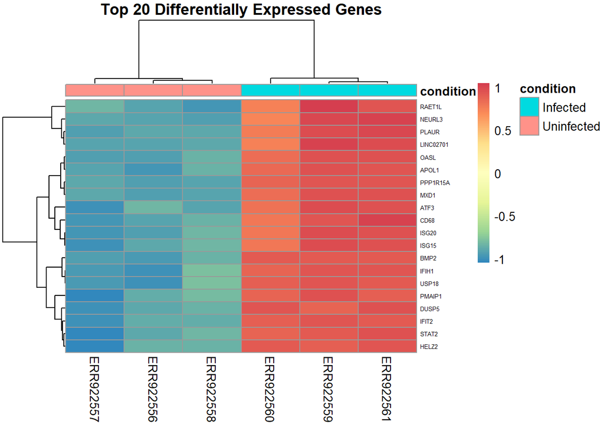

**A searchable table of statistically significant DEGs**:

|  | ENSEMBL | SYMBOL | log2FoldChange | padj |
| --- | --- | --- | --- | --- |
| 257 | ENSG00000087074 | PPP1R15A | -3.57519570114585 | 0 |
| 713 | ENSG00000119922 | IFIT2 | -6.98735441235001 | 0 |
| 1003 | ENSG00000135114 | OASL | -6.72754655850843 | 0 |
| 1094 | ENSG00000138166 | DUSP5 | -4.18722003063774 | 0 |
| 46 | ENSG00000011422 | PLAUR | -4.73472615738841 | 1.16172466866411e-242 |
| 334 | ENSG00000100342 | APOL1 | -3.44970216287258 | 5.44994772406062e-225 |
| 119 | ENSG00000059728 | MXD1 | -3.32458996708071 | 3.68208245390186e-217 |
| 1571 | ENSG00000163121 | NEURL3 | -6.20532431634532 | 3.68208245390186e-217 |
| 609 | ENSG00000115267 | IFIH1 | -3.86232942949771 | 8.41282612312747e-206 |
| 1888 | ENSG00000172183 | ISG20 | -4.24770521157685 | 2.27877776921888e-205 |

[output cut: 4343 more lines]

# Gene Set Enrichment Analysis (GSEA)

GSEA determines if a predefined set of genes is statistically significant between different conditions. In this analysis, MSigDB’s [C5 gene ontology gene sets](https://www.gsea-msigdb.org/gsea/msigdb/collections.jsp) is used to identify sets of genes associated with biological pathways.

### GSEA metrics

In order to perform GSEA on the DEGs, a GSEA metric was created by finding -log10(padj) * sign(log2FoldChange) for each DEG. The frequencies of values of this metric are reported in a histogram below. While most values are clustered around 0, the maximum and minimum values are 155.3 and -307.7 respectively.

**Histogram of frequencies of GSEA metrics:**

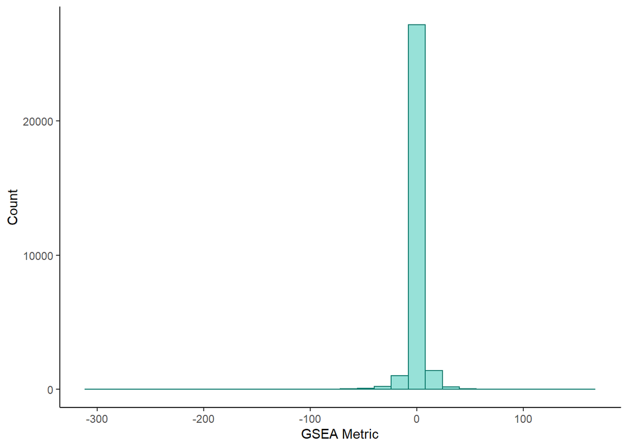

## Performing GSEA

Using rankings created from the GSEA metric calculated above and the C5 gene set from MSigDB, GSEA is performed using clusterProfiler. The enriched pathways found through GSEA are reported in the table below. As well as the pathway’s ID, its raw enrichment score, its normalised enrichment score (NES) and p-adjusted score are given.

**A searchable table of GSEA pathways:**

|  | enrichmentScore | NES | p.adjust |
| --- | --- | --- | --- |
| GO_DNA_PACKAGING_COMPLEX | 0.866002620267265 | 2.19517921484252 | 9.393e-08 |
| GO_NUCLEOSOME_ORGANIZATION | 0.794129526085345 | 2.14348981934823 | 9.393e-08 |
| GO_NUCLEOSOME_ASSEMBLY | 0.815497654355304 | 2.13117132020872 | 9.393e-08 |
| GO_PROTEIN_DNA_COMPLEX_SUBUNIT_ORGANIZATION | 0.734567597805949 | 2.11493028093581 | 9.393e-08 |
| GO_DNA_REPLICATION_INDEPENDENT_NUCLEOSOME_ORGANIZATION | 0.838883029584695 | 1.95883342528176 | 0.000131898223257422 |
| GO_NEGATIVE_REGULATION_OF_GENE_EXPRESSION_EPIGENETIC | 0.757120570316518 | 1.95241846693911 | 7.36211995208242e-06 |
| GO_CHROMATIN_ASSEMBLY_OR_DISASSEMBLY | 0.702410907336914 | 1.94386034427733 | 2.43418680636608e-06 |
| GO_DNA_CONFORMATION_CHANGE | 0.659910756847215 | 1.94332089602466 | 9.393e-08 |
| GO_KINETOCHORE | 0.737989940513923 | 1.93824723347832 | 3.47336195643406e-06 |
| GO_CHROMATIN_REMODELING_AT_CENTROMERE | 0.832792056228861 | 1.91518678072213 | 0.000602561486796595 |

[output cut: 335 more lines]

**Reporting the 5 most overexpressed pathways:**

|  | Top.5.Overrepresented.Pathways | Freq |
| --- | --- | --- |
| 1 | GO_DNA_PACKAGING_COMPLEX | 1 |
| 2 | GO_DNA_REPLICATION_INDEPENDENT_NUCLEOSOME_ORGANIZATION | 1 |
| 3 | GO_NUCLEOSOME_ASSEMBLY | 1 |
| 4 | GO_NUCLEOSOME_ORGANIZATION | 1 |
| 5 | GO_PROTEIN_DNA_COMPLEX_SUBUNIT_ORGANIZATION | 1 |

**Reporting the 5 most underexpressed pathways:**

|  | Top.5.Underrepresented.Pathways | Freq |
| --- | --- | --- |
| 1 | GO_DEFENSE_RESPONSE_TO_VIRUS | 1 |
| 2 | GO_INTERFERON_GAMMA_MEDIATED_SIGNALING_PATHWAY | 1 |
| 3 | GO_RESPONSE_TO_INTERFERON_GAMMA | 1 |
| 4 | GO_RESPONSE_TO_TYPE_I_INTERFERON | 1 |
| 5 | GO_RESPONSE_TO_VIRUS | 1 |

## A visualisation of GSEA: Enrichment plot

**Enrichment plot for the most overrepresented pathway, GO_DNA_PACKAGING_COMPLEX:**

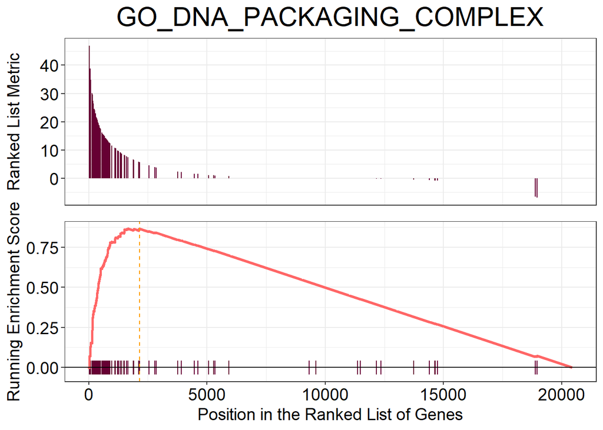

# Analysis

Previous research has found that listeria manipulates chromatin in order to alter cell transcription behaviour and uses its secreted virulence factor LntA to control patients’ gene expression (7). In regards to L. monocytogenes, the production of LntA by these bacteria inhibits the BAHD1 protein from expressing ISGs (Interferon Stimulated Genes) which prevent infection. This allows L. monocytogenes to open the chromatin and acetylate histones. It is suggested that L. monocytogenes may do this in a controlled and intentional way in order to modulate ISG expression during colonisation (8)

In order to expand upon my findings, it would be interesting to analyse RNA data extracted at different points in the infection from multiple patients, to hopefully see when BAHD1 inhibition was at its greatest. It would also be good to perform my analyses on a larger sample to see if my results from this (small) study were corroborated.

### Sources

1. http://amigo.geneontology.org/amigo/term/GO:0034728
2. http://amigo.geneontology.org/amigo/term/GO:0006334
3. Hanna Leins, Medhanie Mulaw, Karina Eiwen, Vadim Sakk, Ying Liang, Michael Denkinger, Hartmut Geiger, Reinhold Schirmbeck; Aged murine hematopoietic stem cells drive aging-associated immune remodeling. Blood 2018; 132 (6): 565–576
4. Luscombe, N.M., Austin, S.E., Berman, H.M. et al. An overview of the structures of protein-DNA complexes. Genome Biol 1, reviews001.1 (2000)
5. http://amigo.geneontology.org/amigo/term/GO:0071824
6. http://amigo.geneontology.org/amigo/term/GO:0045814
7. Lebreton A, Lakisic G, Job V, et al. A Bacterial Protein Targets the BAHD1 Chromatin Complex to Stimulate Type III Interferon Response. Science. 2011;331(6022):1319
8. Bierne, H, Hamon, M. Targeting host epigenetic machinery: The Listeria paradigm. Cellular Microbiology. 2020; 22:e13169
9. Lebreton A, Job V, Ragon M, et al. Structural Basis for the Inhibition of the Chromatin Repressor BAHD1 by the Bacterial Nucleomodulin LntA. mBio. 2014;5(1):e00775-13